# Fatores raciais e prevalência de distocia

Vanessa Elenia de Brito Masullo

15 junho, 2025

# 1 Contextualização: explicando o nosso banco de dados

Os dados de distócia foram baixados do Portal Transferências de Arquivos: https://datasus.saude.gov.br/transferencia-de-arquivos/. Os arquivos são RD de AIH reduzidas, do período de 2008 a 2023.  
Em seguida, foram tabulados no TabWin, versão 4.1.5 32 bits.  
As tabulações deram-se pelos seguintes descritores: Diagnóstico CID 10, capítulo 15, de 063 a 070.9; UF de internação: Piauí; incremento: frequência; ano de processamento: 2008 a 2023.

# 2 Carregamento dos Pacotes

Os datasets utilizados:

```r
library(conflicted)
library(tidyverse)
library(stats)
library(rstatix)
library(dplyr)
library(readr)
library(pacman)
library(caTools)
library(psych)
library(car)
library(mgcv)
library(tibble)
library(rgl)
library(ggplot2)
library(knitr)
library(kableExtra)
library(ggpubr)
library(dunn.test)
library(car)
library(rlang)
```

# 3 Análise dos limites das variáveis quantitativas, por grupo de parturientes

```
Tabela 1: analise quantitativa: variância, desvio padrão, mediana e intervalo interquartil
```

```r
# Definindo os vetores com os dados
branca <- c(77, 124, 2, 428, 56, 0, 1116, 13, 8)
preta <- c(32, 25, 0, 124, 69, 0, 192, 4, 9)
parda <- c(1447, 1325, 39, 10731, 1645, 6, 9948, 1147, 285)

# Função para calcular as estatísticas de cada grupo
calcular_estatisticas <- function(dados, nome_grupo) {
  cat("\n--- Estatísticas para o grupo", nome_grupo, "---\n")
  cat("Média:", mean(dados), "\n")
  cat("Mediana:", median(dados), "\n")
  cat("Desvio Padrão:", sd(dados), "\n")
  cat("Variância:", var(dados), "\n")
  cat("Intervalo Interquartil (IQR):", IQR(dados), "\n")
  cat("Mínimo-Máximo:", range(dados), "\n")
  cat("Resumo Estatístico:\n")
  print(summary(dados))
}

# Aplicando a função para cada grupo
calcular_estatisticas(branca, "Branca")
```

```
##
## --- Estatísticas para o grupo Branca ---
## Média: 202.6667
## Mediana: 56
## Desvio Padrão: 368.0445
## Variância: 135456.8
## Intervalo Interquartil (IQR): 116
## Mínimo-Máximo: 0 1116
## Resumo Estatístico:
##    Min. 1st Qu.  Median    Mean 3rd Qu.    Max.
##     0.0     8.0    56.0   202.7   124.0  1116.0
```

```r
calcular_estatisticas(preta, "Preta")
```

```
##
## --- Estatísticas para o grupo Preta ---
## Média: 50.55556
## Mediana: 25
## Desvio Padrão: 66.84331
## Variância: 4468.028
## Intervalo Interquartil (IQR): 65
## Mínimo-Máximo: 0 192
## Resumo Estatístico:
##    Min. 1st Qu.  Median    Mean 3rd Qu.    Max.
##    0.00    4.00   25.00   50.56   69.00  192.00
```

```r
calcular_estatisticas(parda, "Parda")
```

```
##
## --- Estatísticas para o grupo Parda ---
## Média: 2952.556
## Mediana: 1325
## Desvio Padrão: 4236.931
## Variância: 17951582
## Intervalo Interquartil (IQR): 1360
## Mínimo-Máximo: 6 10731
## Resumo Estatístico:
##    Min. 1st Qu.  Median    Mean 3rd Qu.    Max.
##       6     285    1325    2953    1645   10731
```

# 4 Leitura e visualização do banco de dados “corprev_dist”

```
Dados para as analises do modelo GAM, LOESS e Regressões Múltiplas
```

```r
corprev_dist <- data.frame(
  ANO = c(2008, 2009, 2010, 2011, 2012, 2013, 2014, 2015, 2016, 2017, 2018, 2019, 2020, 2021, 2022, 2023),
  distocia = c(2786, 3735, 3742, 3663, 3408, 3663, 3608, 3594, 2814, 2849, 2968, 3031, 3783, 3684, 3246, 3496),
  Partos_vc = c(44871, 42641, 44224, 45264, 38809, 38730, 37317, 38879, 37136, 35089, 36913, 34737, 31535, 32379, 29541, 28996),
  Prevalencia = c(0.062, 0.087, 0.084, 0.08, 0.087, 0.094, 0.098, 0.092, 0.075, 0.081, 0.08, 0.087, 0.119, 0.113, 0.109, 0.12),
  IDH = c(0.362, 0.484, 0.646, 0.660, 0.679, 0.686, 0.689, 0.685, 0.694, 0.699, 0.706, 0.708, 0.690, 0.690, 0.690, 0.690),
  DMG_parda = c (808, 1193, 1390, 1237, 1389, 1304, 1329, 1265, 1019, 916, 1048, 955, 786, 822, 920, 1467),
  DMG_branca = c(84, 68, 62, 52, 46, 104, 69, 102, 99, 94, 99, 112, 76, 85, 67, 77),
  DMG_preta = c (22, 29, 32, 8, 16, 43, 27, 32, 48, 49, 42, 55, 43, 35, 8, 38),
  obes_def_branca = c (96, 0, 20, 1, 3, 2990, 9840, 18310, 16470, 17460, 19140, 16380, 6600, 1860, 4560, 2100),
  obes_def_parda = c (0,1,8, 47, 3, 422, 691, 18482, 40036, 35651, 39352, 40850, 18950, 6371, 14972, 7804),
  obes_def_preta = c (0, 0, 0, 4, 0, 421, 420, 1260, 540, 511, 151, 150, 170, 80, 320, 840),
  indice_gini = c (0.599, 0.579, 0.558, 0.515, 0.495, 0.535, 0.516, 0.520, 0.528, 0.529, 0.530, 0.537, 0.474, 0.516, 0.518, 0.552),
  Branca = c(182, 154, 177, 175, 150, 123, 93, 109, 83, 86, 95, 88, 121, 49, 23, 114),
  Parda = c(1583, 2152, 2178, 2376, 2158, 2218, 1560, 1528, 1149, 1130, 1258, 1189, 1535, 1040, 934, 2546),
  Preta = c(15, 46, 11, 12, 3, 10, 9, 9, 36, 29, 41, 36, 57, 19, 8, 114),
  CID_068 = c(1260, 1885, 1978, 1668,   1315,   1493,   1472,   1657,   1436,   1357,   1358,   1366,   1562,   1528,   1520,   1516),
  CID_065 = c(909, 1174, 1042, 1161, 1342, 1617, 1442, 1233, 914, 1004, 1016, 899, 835, 988, 712, 712),
  I1 = c(134, 158, 156, 161, 144, 143, 136, 129, 101, 110, 89, 88, 121, 109, 77, 95),
  I2 = c(2657, 3369, 3334, 3239, 3110, 3231, 3376, 3156, 2522, 2582, 2608, 2715, 3385, 3284, 2800, 2881),
  I3 = c(150, 186, 199, 180,    197, 223, 198, 214, 196, 227, 221, 256, 315, 325, 320, 362)
)

library(rmarkdown)
paged_table(corprev_dist)
```

| ANO | distocia | Partos_vc | Prevalencia | IDH | DMG_parda | DMG_branca | DMG_preta | obes_def_branca | obes_def_parda | obes_def_preta | indice_gini | Branca | Parda | Preta | CID_068 | CID_065 | I1 | I2 | I3 |
| --- | --- | --- | --- | --- | --- | --- | --- | --- | --- | --- | --- | --- | --- | --- | --- | --- | --- | --- | --- |
| 2008 | 2786 | 44871 | 0.062 | 0.362 | 808 | 84 | 22 | 96 | 0 | 0 | 0.599 | 182 | 1583 | 15 | 1260 | 909 | 134 | 2657 | 150 |
| 2009 | 3735 | 42641 | 0.087 | 0.484 | 1193 | 68 | 29 | 0 | 1 | 0 | 0.579 | 154 | 2152 | 46 | 1885 | 1174 | 158 | 3369 | 186 |
| 2010 | 3742 | 44224 | 0.084 | 0.646 | 1390 | 62 | 32 | 20 | 8 | 0 | 0.558 | 177 | 2178 | 11 | 1978 | 1042 | 156 | 3334 | 199 |
| 2011 | 3663 | 45264 | 0.080 | 0.660 | 1237 | 52 | 8 | 1 | 47 | 4 | 0.515 | 175 | 2376 | 12 | 1668 | 1161 | 161 | 3239 | 180 |
| 2012 | 3408 | 38809 | 0.087 | 0.679 | 1389 | 46 | 16 | 3 | 3 | 0 | 0.495 | 150 | 2158 | 3 | 1315 | 1342 | 144 | 3110 | 197 |
| 2013 | 3663 | 38730 | 0.094 | 0.686 | 1304 | 104 | 43 | 2990 | 422 | 421 | 0.535 | 123 | 2218 | 10 | 1493 | 1617 | 143 | 3231 | 223 |
| 2014 | 3608 | 37317 | 0.098 | 0.689 | 1329 | 69 | 27 | 9840 | 691 | 420 | 0.516 | 93 | 1560 | 9 | 1472 | 1442 | 136 | 3376 | 198 |
| 2015 | 3594 | 38879 | 0.092 | 0.685 | 1265 | 102 | 32 | 18310 | 18482 | 1260 | 0.520 | 109 | 1528 | 9 | 1657 | 1233 | 129 | 3156 | 214 |
| 2016 | 2814 | 37136 | 0.075 | 0.694 | 1019 | 99 | 48 | 16470 | 40036 | 540 | 0.528 | 83 | 1149 | 36 | 1436 | 914 | 101 | 2522 | 196 |
| 2017 | 2849 | 35089 | 0.081 | 0.699 | 916 | 94 | 49 | 17460 | 35651 | 511 | 0.529 | 86 | 1130 | 29 | 1357 | 1004 | 110 | 2582 | 227 |

[output cut: 6 more lines]

## 4.1 Pressupostos de normalidade da variável IDH

Variável não paramétrica

```r
shapiro.test(corprev_dist$IDH)
```

```
##
##  Shapiro-Wilk normality test
##
## data:  corprev_dist$IDH
## W = 0.55148, p-value = 5.84e-06
```

## 4.2 Pressuposto de normalidade da variável Prevalência

Variável paramétrica

```r
shapiro.test(corprev_dist$Prevalencia)
```

```
##
##  Shapiro-Wilk normality test
##
## data:  corprev_dist$Prevalencia
## W = 0.94128, p-value = 0.365
```

## 4.3 Gráfico com linha de tendência para visualização da prevalência

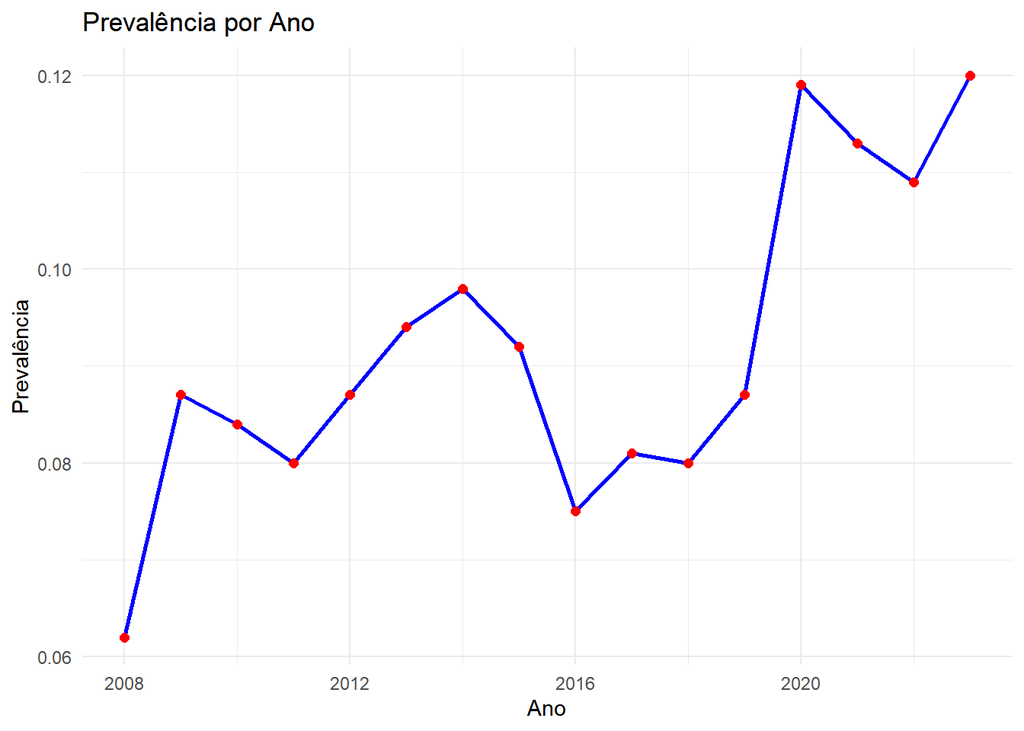

```r
library(ggplot2)

dados <- data.frame(
  ANO = c(2008:2023),
  Prevalencia = c(0.062, 0.087, 0.084, 0.08, 0.087, 0.094, 0.098, 0.092,
                 0.075, 0.081, 0.08, 0.087, 0.119, 0.113, 0.109, 0.12)
)

ggplot(dados, aes(x = ANO, y = Prevalencia)) +
  geom_line(color = "blue", linewidth = 1) +
  geom_point(color = "red", size = 2) +
  labs(title = "Prevalência por Ano", x = "Ano", y = "Prevalência") +
  theme_minimal()
```

## 4.4 Correlação de Kendall

Análise da correlação entre o IDH e a Prevalência Bruta

```r
cor.test(corprev_dist$IDH, corprev_dist$Prevalencia , method = "kendall", exact = FALSE, simulate.p.value = TRUE, B = 10000)
```

```
##
##  Kendall's rank correlation tau
##
## data:  corprev_dist$IDH and corprev_dist$Prevalencia
## z = 1.1865, p-value = 0.2354
## alternative hypothesis: true tau is not equal to 0
## sample estimates:
##       tau
## 0.2260955
```

## 4.5 Pressupostos de normalidade da variável índice_gini

Variável paramétrica

```r
shapiro.test(corprev_dist$indice_gini)
```

```
##
##  Shapiro-Wilk normality test
##
## data:  corprev_dist$indice_gini
## W = 0.94889, p-value = 0.4723
```

## 4.6 Correlação de Pearson entre as variáveis Prevalência e indice_gini

```r
cor.test(corprev_dist$Prevalencia, corprev_dist$indice_gini , method = "pearson", exact = FALSE, simulate.p.value = TRUE, B = 10000)
```

```
##
##  Pearson's product-moment correlation
##
## data:  corprev_dist$Prevalencia and corprev_dist$indice_gini
## t = -2.1035, df = 14, p-value = 0.05398
## alternative hypothesis: true correlation is not equal to 0
## 95 percent confidence interval:
##  -0.793095717  0.007470983
## sample estimates:
##        cor
## -0.4900492
```

# 5 Análise do relacionamento entre as variáveis IDH e Prevalencia pelo Modelo Aditivo Generalizado (GAM).

Como a correlação linear de Kendall não foi significativa, ajustamos o modelo GAM para interpretar a dispersão observarda pelo efeito temporal.

```r
# Ajustar o GAM em k=5: para evitar overfitting
modelo_gam_temporal <- gam(
  Prevalencia ~ s(IDH, k = 5, bs = "cr") + s(ANO, k = 5, bs = "cr"),
  data = corprev_dist,
  method = "REML"
)

## Verificar o modelo
summary(modelo_gam_temporal)
```

```
##
## Family: gaussian
## Link function: identity
##
## Formula:
## Prevalencia ~ s(IDH, k = 5, bs = "cr") + s(ANO, k = 5, bs = "cr")
##
## Parametric coefficients:
##             Estimate Std. Error t value Pr(>|t|)
## (Intercept) 0.091750   0.002046   44.85 4.14e-14 ***
## ---
## Signif. codes:  0 '***' 0.001 '**' 0.01 '*' 0.05 '.' 0.1 ' ' 1
##
## Approximate significance of smooth terms:
##          edf Ref.df      F p-value
## s(IDH) 2.677  2.974  4.892  0.0178 *
## s(ANO) 1.000  1.000 29.863  0.0002 ***
## ---
## Signif. codes:  0 '***' 0.001 '**' 0.01 '*' 0.05 '.' 0.1 ' ' 1
##
## R-sq.(adj) =   0.75   Deviance explained = 81.1%
## -REML = -39.723  Scale est. = 6.6952e-05  n = 16
```

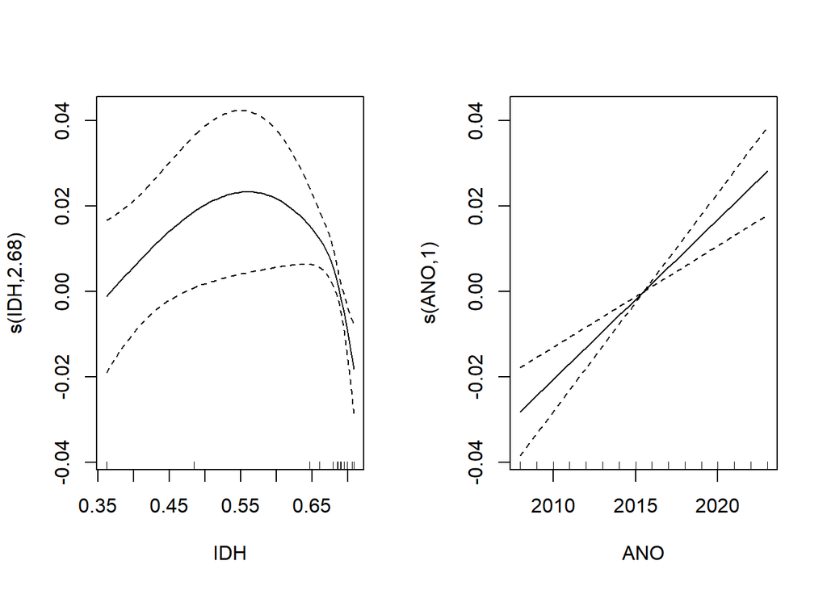

```r
plot(modelo_gam_temporal, pages = 1)
```

```r
### Para a verificação do efeito temporal

library(mgcv)
library(ggplot2)
library(plotly)

#### Ajuste do Modelo com Efeito Temporal
modelo_gam_temporal <- gam(
  Prevalencia ~ s(IDH, k = 5, bs = "cr") + s(ANO, k = 5, bs = "cr"),
  data = corprev_dist,
  method = "REML"  # Método mais estável para pequenos datasets
)

##### Sumário do Modelo (Verificando a significância dos termos)
summary(modelo_gam_temporal)
```

```
##
## Family: gaussian
## Link function: identity
##
## Formula:
## Prevalencia ~ s(IDH, k = 5, bs = "cr") + s(ANO, k = 5, bs = "cr")
##
## Parametric coefficients:
##             Estimate Std. Error t value Pr(>|t|)
## (Intercept) 0.091750   0.002046   44.85 4.14e-14 ***
## ---
## Signif. codes:  0 '***' 0.001 '**' 0.01 '*' 0.05 '.' 0.1 ' ' 1
##
## Approximate significance of smooth terms:
##          edf Ref.df      F p-value
## s(IDH) 2.677  2.974  4.892  0.0178 *
## s(ANO) 1.000  1.000 29.863  0.0002 ***
## ---
## Signif. codes:  0 '***' 0.001 '**' 0.01 '*' 0.05 '.' 0.1 ' ' 1
##
## R-sq.(adj) =   0.75   Deviance explained = 81.1%
## -REML = -39.723  Scale est. = 6.6952e-05  n = 16
```

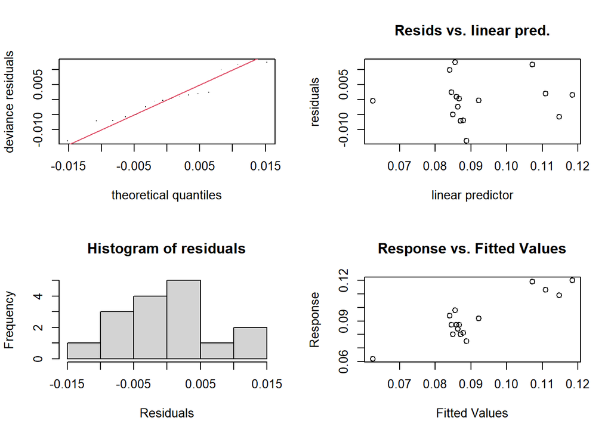

```
##
## Method: REML   Optimizer: outer newton
## full convergence after 9 iterations.
## Gradient range [-2.047701e-05,7.426594e-06]
## (score -39.72291 & scale 6.695245e-05).
## Hessian positive definite, eigenvalue range [2.047618e-05,6.614171].
## Model rank =  9 / 9
##
## Basis dimension (k) checking results. Low p-value (k-index<1) may
## indicate that k is too low, especially if edf is close to k'.
##
##          k'  edf k-index p-value
## s(IDH) 4.00 2.68    0.54   0.015 *
## s(ANO) 4.00 1.00    0.67   0.040 *
## ---
## Signif. codes:  0 '***' 0.001 '**' 0.01 '*' 0.05 '.' 0.1 ' ' 1
```

```r
####### Diagnóstico do Modelo
gam.check(modelo_gam_temporal)  # Verificando resíduos e pressupostos
```

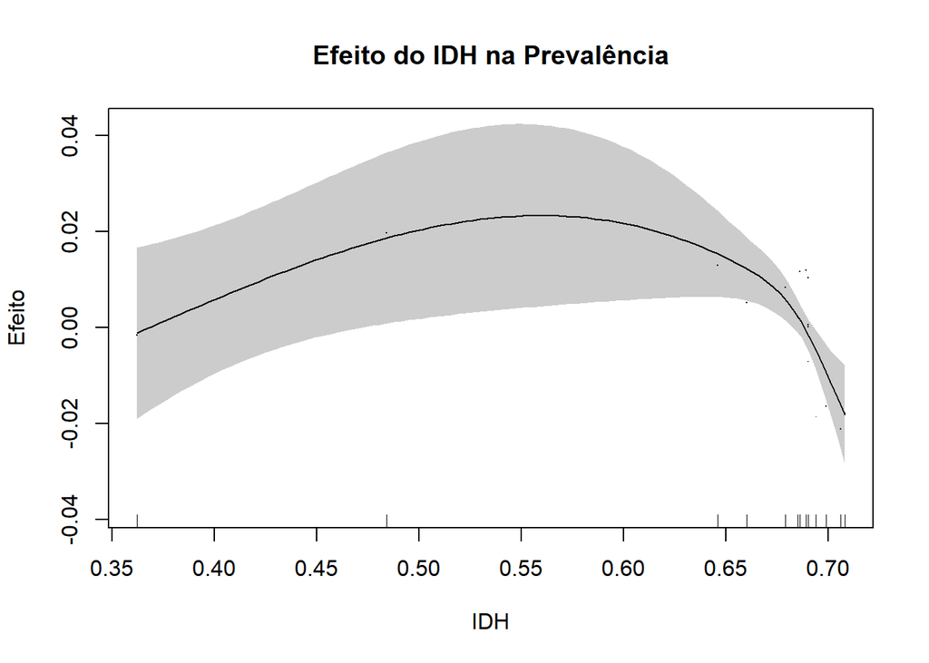

```r
#######Efeito de IDH
plot(modelo_gam_temporal, select = 1, shade = TRUE, residuals = TRUE,
     main = "Efeito do IDH na Prevalência", xlab = "IDH", ylab = "Efeito")
```

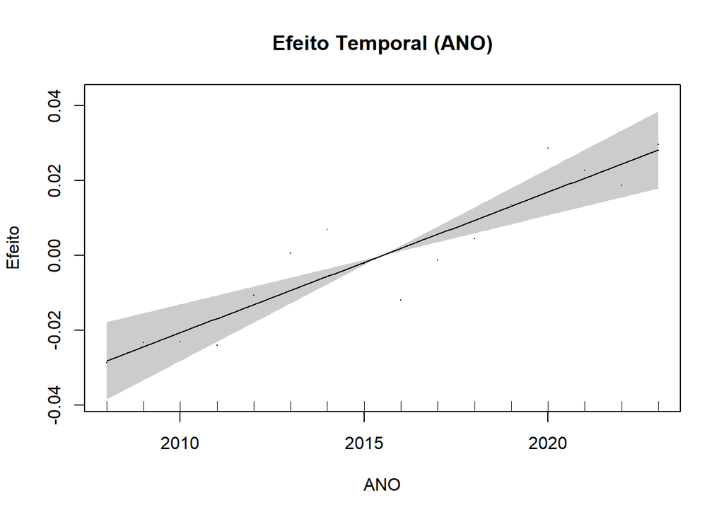

```r
######### Efeito do ANO
plot(modelo_gam_temporal, select = 2, shade = TRUE, residuals = TRUE,
     main = "Efeito Temporal (ANO)", xlab = "ANO", ylab = "Efeito")
```

## 5.1 Análise do relacionamento entre as variáveis Prevalencia e indice_gini pelo modelo LOESS

(Locally Estimated Scatterplot Smoothing).  
O modelo ajusta uma curva suave aos dados, capturando tendências locais sem assumir uma forma funcional global.

```r
# 5.1 criação e ajuste do modelo para span = 0.75 # Esse span controla o grau de suavização do ajuste

modelo_loessgini <- loess(Prevalencia ~ indice_gini, data = corprev_dist, span = 0.75)
# 5.1. Adicionar valores preditos ao dataframe
corprev_dist$predito <- predict(modelo_loessgini)

# 5.2. Gráfico com cores por ano e curva LOESS - curva do modelo LOESS, com a variável ANO.
library(ggplot2)

# 5.3. Converter 'ANO' para fator ANTES de usar no gráfico
corprev_dist$ANO <- as.factor(corprev_dist$ANO)
glimpse(corprev_dist)
```

```
## Rows: 16
## Columns: 21
## $ ANO             <fct> 2008, 2009, 2010, 2011, 2012, 2013, 2014, 2015, 2016, …
## $ distocia        <dbl> 2786, 3735, 3742, 3663, 3408, 3663, 3608, 3594, 2814, …
## $ Partos_vc       <dbl> 44871, 42641, 44224, 45264, 38809, 38730, 37317, 38879…
## $ Prevalencia     <dbl> 0.062, 0.087, 0.084, 0.080, 0.087, 0.094, 0.098, 0.092…
## $ IDH             <dbl> 0.362, 0.484, 0.646, 0.660, 0.679, 0.686, 0.689, 0.685…
## $ DMG_parda       <dbl> 808, 1193, 1390, 1237, 1389, 1304, 1329, 1265, 1019, 9…
## $ DMG_branca      <dbl> 84, 68, 62, 52, 46, 104, 69, 102, 99, 94, 99, 112, 76,…
## $ DMG_preta       <dbl> 22, 29, 32, 8, 16, 43, 27, 32, 48, 49, 42, 55, 43, 35,…
## $ obes_def_branca <dbl> 96, 0, 20, 1, 3, 2990, 9840, 18310, 16470, 17460, 1914…
## $ obes_def_parda  <dbl> 0, 1, 8, 47, 3, 422, 691, 18482, 40036, 35651, 39352, …
## $ obes_def_preta  <dbl> 0, 0, 0, 4, 0, 421, 420, 1260, 540, 511, 151, 150, 170…
## $ indice_gini     <dbl> 0.599, 0.579, 0.558, 0.515, 0.495, 0.535, 0.516, 0.520…
## $ Branca          <dbl> 182, 154, 177, 175, 150, 123, 93, 109, 83, 86, 95, 88,…
## $ Parda           <dbl> 1583, 2152, 2178, 2376, 2158, 2218, 1560, 1528, 1149, …
## $ Preta           <dbl> 15, 46, 11, 12, 3, 10, 9, 9, 36, 29, 41, 36, 57, 19, 8…
## $ CID_068         <dbl> 1260, 1885, 1978, 1668, 1315, 1493, 1472, 1657, 1436, …
## $ CID_065         <dbl> 909, 1174, 1042, 1161, 1342, 1617, 1442, 1233, 914, 10…
## $ I1              <dbl> 134, 158, 156, 161, 144, 143, 136, 129, 101, 110, 89, …
## $ I2              <dbl> 2657, 3369, 3334, 3239, 3110, 3231, 3376, 3156, 2522, …
## $ I3              <dbl> 150, 186, 199, 180, 197, 223, 198, 214, 196, 227, 221,…
## $ predito         <dbl> 0.06132522, 0.08854452, 0.10137404, 0.09630383, 0.0961…
```

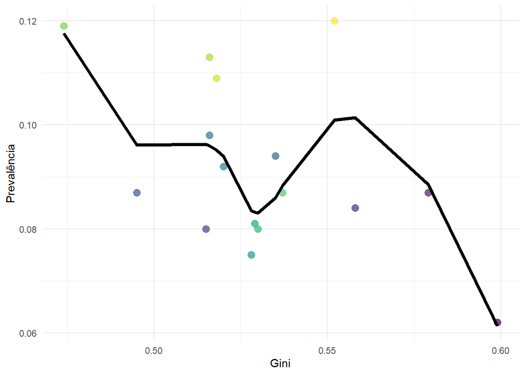

```r
# 5.3 Gráfico
ggplot(corprev_dist, aes(x = indice_gini, y = Prevalencia, color = ANO)) +
  geom_point(size = 3, alpha = 0.7) +                     # Pontos coloridos por ANO
  geom_line(aes(y = predito), color = "black", linewidth = 1.5) +  # Linha LOESS em preto
  labs(x = "Gini", y = "Prevalência") +                   # Rótulos dos eixos
  scale_color_viridis_d(guide = "none") +                 # Cores viridis, mas SEM legenda
  theme_minimal()                                         # Estilo limpo
```

```r
summary(modelo_loessgini)
```

```
## Call:
## loess(formula = Prevalencia ~ indice_gini, data = corprev_dist,
##     span = 0.75)
##
## Number of Observations: 16
## Equivalent Number of Parameters: 5.53
## Residual Standard Error: 0.01335
## Trace of smoother matrix: 6.11  (exact)
##
## Control settings:
##   span     :  0.75
##   degree   :  2
##   family   :  gaussian
##   surface  :  interpolate      cell = 0.2
##   normalize:  TRUE
##  parametric:  FALSE
## drop.square:  FALSE
```

```r
library(tidyverse)

glimpse(corprev_dist) # visualizar o predito e variável dependente (Prevalência)
```

```
## Rows: 16
## Columns: 21
## $ ANO             <fct> 2008, 2009, 2010, 2011, 2012, 2013, 2014, 2015, 2016, …
## $ distocia        <dbl> 2786, 3735, 3742, 3663, 3408, 3663, 3608, 3594, 2814, …
## $ Partos_vc       <dbl> 44871, 42641, 44224, 45264, 38809, 38730, 37317, 38879…
## $ Prevalencia     <dbl> 0.062, 0.087, 0.084, 0.080, 0.087, 0.094, 0.098, 0.092…
## $ IDH             <dbl> 0.362, 0.484, 0.646, 0.660, 0.679, 0.686, 0.689, 0.685…
## $ DMG_parda       <dbl> 808, 1193, 1390, 1237, 1389, 1304, 1329, 1265, 1019, 9…
## $ DMG_branca      <dbl> 84, 68, 62, 52, 46, 104, 69, 102, 99, 94, 99, 112, 76,…
## $ DMG_preta       <dbl> 22, 29, 32, 8, 16, 43, 27, 32, 48, 49, 42, 55, 43, 35,…
## $ obes_def_branca <dbl> 96, 0, 20, 1, 3, 2990, 9840, 18310, 16470, 17460, 1914…
## $ obes_def_parda  <dbl> 0, 1, 8, 47, 3, 422, 691, 18482, 40036, 35651, 39352, …
## $ obes_def_preta  <dbl> 0, 0, 0, 4, 0, 421, 420, 1260, 540, 511, 151, 150, 170…
## $ indice_gini     <dbl> 0.599, 0.579, 0.558, 0.515, 0.495, 0.535, 0.516, 0.520…
## $ Branca          <dbl> 182, 154, 177, 175, 150, 123, 93, 109, 83, 86, 95, 88,…
## $ Parda           <dbl> 1583, 2152, 2178, 2376, 2158, 2218, 1560, 1528, 1149, …
## $ Preta           <dbl> 15, 46, 11, 12, 3, 10, 9, 9, 36, 29, 41, 36, 57, 19, 8…
## $ CID_068         <dbl> 1260, 1885, 1978, 1668, 1315, 1493, 1472, 1657, 1436, …
## $ CID_065         <dbl> 909, 1174, 1042, 1161, 1342, 1617, 1442, 1233, 914, 10…
## $ I1              <dbl> 134, 158, 156, 161, 144, 143, 136, 129, 101, 110, 89, …
## $ I2              <dbl> 2657, 3369, 3334, 3239, 3110, 3231, 3376, 3156, 2522, …
## $ I3              <dbl> 150, 186, 199, 180, 197, 223, 198, 214, 196, 227, 221,…
## $ predito         <dbl> 0.06132522, 0.08854452, 0.10137404, 0.09630383, 0.0961…
```

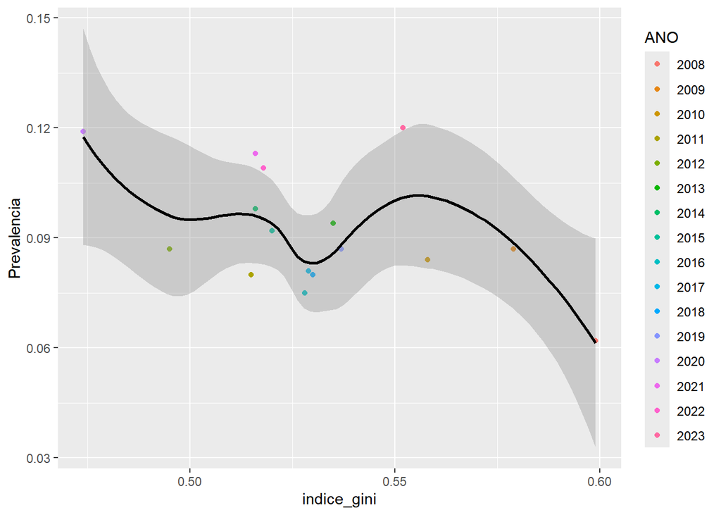

```r
# 5.4 adicionar intervalos de confiança no modelo LOESS
ggplot(corprev_dist, aes(indice_gini, Prevalencia)) +
  geom_point(aes(color = ANO)) +
  geom_smooth(method = "loess", se = TRUE, color = "black")  # se = TRUE mostra IC
```

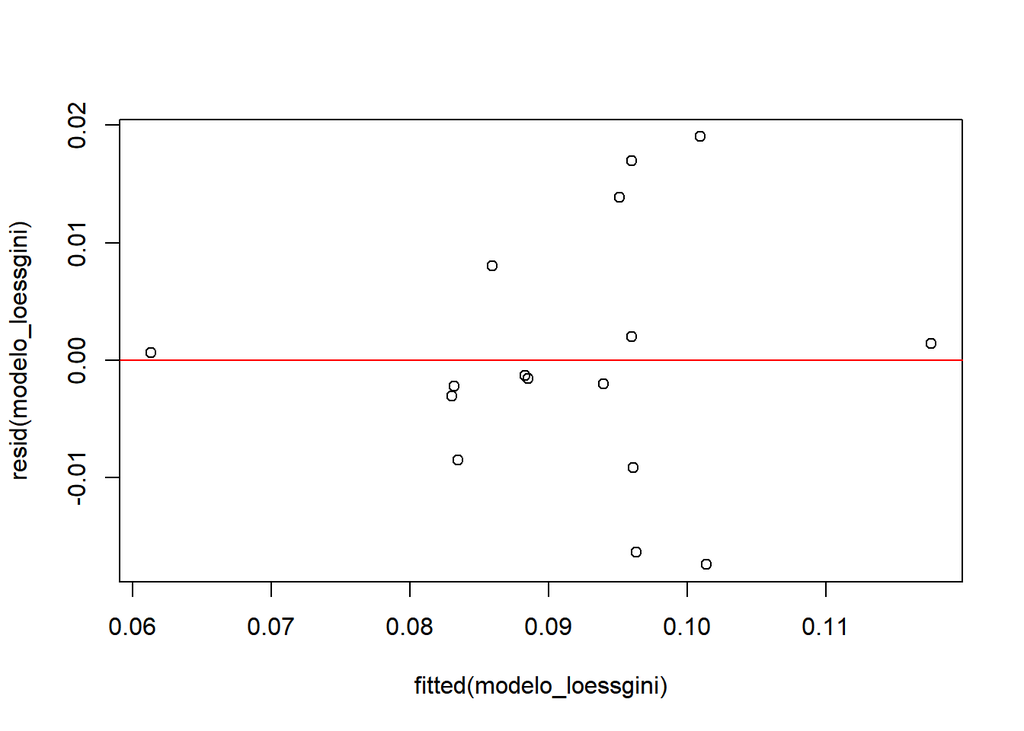

```r
# 5.5 Analisar dispesão de residuos ao redor do zero: resíduos devem estar aleatoriamente distribuídos em torno de zero

plot(resid(modelo_loessgini) ~ fitted(modelo_loessgini))
abline(h = 0, col = "red")
```

# 6 Leitura e visualização do banco de dados para o Kruskal-Wallis

```r
dados <- data.frame(
  grupos = c("branca", "branca", "branca", "branca", "branca", "branca", "branca",
             "branca", "branca", "branca", "branca", "branca", "branca", "branca",
             "branca", "branca", "preta", "preta", "preta", "preta", "preta", "preta",
             "preta", "preta", "preta", "preta", "preta", "preta", "preta", "preta",
             "preta", "preta", "parda", "parda", "parda", "parda", "parda", "parda",
             "parda", "parda", "parda", "parda", "parda", "parda", "parda", "parda",
             "parda", "parda"),  # <- 48 valores
  CID63 = c(6, 1, 0, 0, 0, 1, 0, 1, 4, 3, 8, 13, 7, 4, 9, 20, 1, 1, 0, 0, 0, 0, 0,
            1, 2, 1, 4, 6, 7, 1, 1, 7, 88, 115, 131, 187, 111, 97, 63, 82, 87, 85,
            102, 105, 56, 23, 23, 92),  # 48 valores
  CID64 = c(18, 8, 11, 8, 20, 5, 1, 0, 5, 2, 6, 9, 11, 8, 1, 11, 1, 0, 2, 1, 0, 0,
            0, 0, 3, 2, 1, 3, 2, 0, 1, 9, 71, 111, 100, 73, 109, 73, 31, 34, 40, 58,
            84, 67, 102, 82, 87, 203),  # 48 valores
  CID65 = c(19, 27, 25, 34, 32, 49, 29, 33, 28, 29, 30, 30, 27, 17, 4, 15, 3, 25, 2,
            5, 0, 5, 1, 3, 18, 11, 12, 10, 9, 7, 4, 9, 714, 915, 745, 816, 908, 1045,
            945, 745, 475, 522, 610, 502, 512, 454, 285, 538),  # 48 valores
  CID66 = c(0, 0, 0, 0, 0, 0, 1, 0, 0, 1, 1, 4, 19, 1, 2, 27, 4, 1, 1, 0, 0, 0, 0,
            0, 0, 1, 3, 1, 9, 1, 0, 48, 98, 109, 132, 140, 159, 61, 11, 16, 12, 11,
            13, 33, 210, 82, 114, 444),  # 48 valores
  CID67 = c(0, 0, 0, 0, 0, 0, 0, 0, 0, 0, 0, 0, 0, 0, 0, 0, 0, 0, 0, 0, 0, 0, 0, 0,
            0, 0, 0, 0, 0, 0, 0, 0, 0, 0, 0, 0, 0, 0, 1, 1, 1, 0, 0, 0, 0, 1, 0, 2),  # 48 valores
  CID68 = c(138, 117, 141, 133, 98, 68, 60, 74, 45, 50, 46, 31, 55, 19, 7, 34, 6,
            19, 5, 6, 3, 5, 6, 5, 13, 14, 21, 15, 27, 9, 2, 36, 419, 659, 841, 907,
            743, 897, 503, 641, 522, 443, 433, 437, 612, 380, 411, 1100),  # 48 valores
  CID69 = c(1, 1, 0, 0, 0, 0, 2, 1, 1, 1, 4, 1, 1, 0, 0, 0, 0, 0, 1, 0, 0, 0, 2, 0,
            0, 0, 0, 0, 0, 0, 0, 1, 173, 232, 214, 231, 119, 41, 6, 7, 9, 7, 10, 41,
            16, 11, 11, 19),  # 48 valores
  CID70 = c(0, 0, 0, 0, 0, 0, 0, 0, 0, 0, 0, 0, 1, 0, 0, 7, 0, 0, 0, 0, 0, 0, 0, 0,
            0, 0, 0, 1, 3, 1, 0, 4, 20, 11, 15, 22, 9, 4, 0, 2, 3, 4, 6, 4, 27, 7, 3,
            148)  # 48 valores
)

# Verificar se todas as colunas têm 48 linhas:
sapply(dados, length)
```

```
## grupos  CID63  CID64  CID65  CID66  CID67  CID68  CID69  CID70
##     48     48     48     48     48     48     48     48     48
```

```r
# Visualizar as primeiras linhas do data.frame
head(dados)
```

```
##   grupos CID63 CID64 CID65 CID66 CID67 CID68 CID69 CID70
## 1 branca     6    18    19     0     0   138     1     0
## 2 branca     1     8    27     0     0   117     1     0
## 3 branca     0    11    25     0     0   141     0     0
## 4 branca     0     8    34     0     0   133     0     0
## 5 branca     0    20    32     0     0    98     0     0
## 6 branca     1     5    49     0     0    68     0     0
```

```r
library(rmarkdown)
paged_table(dados)
```

| grupos | CID63 | CID64 | CID65 | CID66 | CID67 | CID68 | CID69 | CID70 |
| --- | --- | --- | --- | --- | --- | --- | --- | --- |
| branca | 6 | 18 | 19 | 0 | 0 | 138 | 1 | 0 |
| branca | 1 | 8 | 27 | 0 | 0 | 117 | 1 | 0 |
| branca | 0 | 11 | 25 | 0 | 0 | 141 | 0 | 0 |
| branca | 0 | 8 | 34 | 0 | 0 | 133 | 0 | 0 |
| branca | 0 | 20 | 32 | 0 | 0 | 98 | 0 | 0 |
| branca | 1 | 5 | 49 | 0 | 0 | 68 | 0 | 0 |
| branca | 0 | 1 | 29 | 1 | 0 | 60 | 2 | 0 |
| branca | 1 | 0 | 33 | 0 | 0 | 74 | 1 | 0 |
| branca | 4 | 5 | 28 | 0 | 0 | 45 | 1 | 0 |
| branca | 3 | 2 | 29 | 1 | 0 | 50 | 1 | 0 |

[output cut: 38 more lines]

## 6.1 Kruskal-Wallis

[output not shown]

```r
kruskal.test(CID63 ~ grupos, data = dados)
```

```
##
##  Kruskal-Wallis rank sum test
##
## data:  CID63 by grupos
## Kruskal-Wallis chi-squared = 32.593, df = 2, p-value = 8.366e-08
```

```r
kruskal.test(CID64 ~ grupos, data = dados)
```

```
##
##  Kruskal-Wallis rank sum test
##
## data:  CID64 by grupos
## Kruskal-Wallis chi-squared = 36.51, df = 2, p-value = 1.18e-08
```

```r
kruskal.test(CID65 ~ grupos, data = dados)
```

```
##
##  Kruskal-Wallis rank sum test
##
## data:  CID65 by grupos
## Kruskal-Wallis chi-squared = 39.366, df = 2, p-value = 2.83e-09
```

```r
kruskal.test(CID66 ~ grupos, data = dados)
```

```
##
##  Kruskal-Wallis rank sum test
##
## data:  CID66 by grupos
## Kruskal-Wallis chi-squared = 28.623, df = 2, p-value = 6.088e-07
```

```r
kruskal.test(CID68 ~ grupos, data = dados)
```

```
##
##  Kruskal-Wallis rank sum test
##
## data:  CID68 by grupos
## Kruskal-Wallis chi-squared = 39.727, df = 2, p-value = 2.362e-09
```

```r
kruskal.test(CID69 ~ grupos, data = dados)
```

```
##
##  Kruskal-Wallis rank sum test
##
## data:  CID69 by grupos
## Kruskal-Wallis chi-squared = 35.562, df = 2, p-value = 1.896e-08
```

```r
kruskal.test(CID70 ~ grupos, data = dados)
```

```
##
##  Kruskal-Wallis rank sum test
##
## data:  CID70 by grupos
## Kruskal-Wallis chi-squared = 29.141, df = 2, p-value = 4.699e-07
```

### 6.1.1 Comparação de grupos Bonferroni

```r
# Lista de variáveis a testar
variaveis <- c("CID63", "CID64", "CID65", "CID66", "CID67", "CID68", "CID69", "CID70")

# Aplicar Kruskal-Wallis a cada uma
resultados <- lapply(variaveis, function(var) {
  teste <- kruskal.test(dados[[var]] ~ dados$grupos)
  data.frame(Variavel = var,
             H = teste$statistic,
             p.value = teste$p.value)
})

# Combinar resultados e ajustar p-valores (Bonferroni)
resultados_df <- do.call(rbind, resultados)
resultados_df$p.ajustado <- p.adjust(resultados_df$p.value, method = "bonferroni")

print(resultados_df)
```

```
##                             Variavel        H      p.value   p.ajustado
## Kruskal-Wallis chi-squared     CID63 32.59293 8.366327e-08 6.693062e-07
## Kruskal-Wallis chi-squared1    CID64 36.50964 1.180409e-08 9.443274e-08
## Kruskal-Wallis chi-squared2    CID65 39.36617 2.829730e-09 2.263784e-08
## Kruskal-Wallis chi-squared3    CID66 28.62349 6.088193e-07 4.870554e-06
## Kruskal-Wallis chi-squared4    CID67 10.90909 4.276820e-03 3.421456e-02
## Kruskal-Wallis chi-squared5    CID68 39.72747 2.362047e-09 1.889638e-08
## Kruskal-Wallis chi-squared6    CID69 35.56227 1.895618e-08 1.516494e-07
## Kruskal-Wallis chi-squared7    CID70 29.14142 4.699166e-07 3.759333e-06
```

### 6.1.2 Comparação de grupos Teste Dunn - cid63

```r
# Teste de Dunn para a coluna 63
resultado <- dunn_test(CID63 ~ grupos,
                       data = dados,
                       p.adjust.method = "bonferroni")
print(resultado)
```

```
## # A tibble: 3 × 9
##   .y.   group1 group2    n1    n2 statistic            p      p.adj p.adj.signif
## * <chr> <chr>  <chr>  <int> <int>     <dbl>        <dbl>      <dbl> <chr>
## 1 CID63 branca parda     16    16     4.43  0.00000940      2.82e-5 ****
## 2 CID63 branca preta     16    16    -0.903 0.367           1   e+0 ns
## 3 CID63 parda  preta     16    16    -5.33  0.0000000964    2.89e-7 ****
```

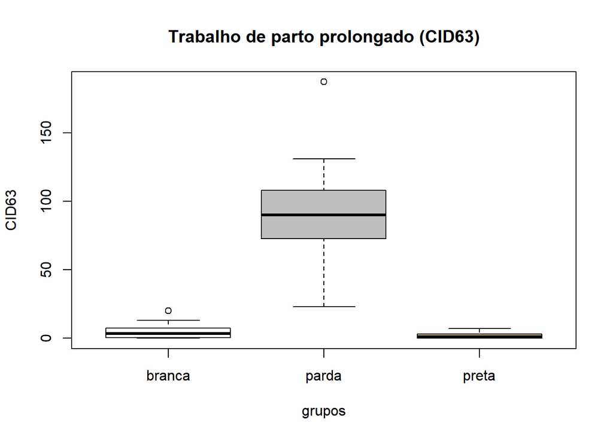

```r
# Boxplot para visualização
boxplot(CID63 ~ grupos,
        data = dados,
        col = c("white", "gray", "tan"),
        main = "Trabalho de parto prolongado (CID63)")
```

### 6.1.3 Comparação de grupos Teste Dunn - cid64

```r
# Teste de Dunn para a coluna 64
resultado <- dunn_test(CID64 ~ grupos,
                       data = dados,
                       p.adjust.method = "bonferroni")
print(resultado)
```

```
## # A tibble: 3 × 9
##   .y.   group1 group2    n1    n2 statistic             p     p.adj p.adj.signif
## * <chr> <chr>  <chr>  <int> <int>     <dbl>         <dbl>     <dbl> <chr>
## 1 CID64 branca parda     16    16      3.75 0.000177        5.32e-4 ***
## 2 CID64 branca preta     16    16     -2.23 0.0258          7.74e-2 ns
## 3 CID64 parda  preta     16    16     -5.98 0.00000000226   6.77e-9 ****
```

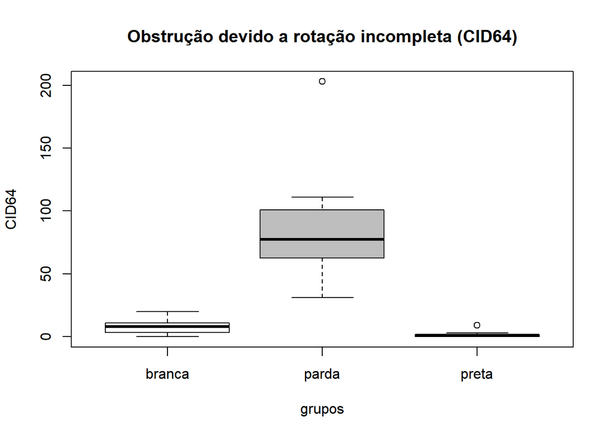

```r
# Boxplot para visualização
boxplot(CID64 ~ grupos,
        data = dados,
        col = c("white", "gray", "tan"),
        main = "Obstrução devido a rotação incompleta (CID64)")
```

### 6.1.4 Comparação de grupos Teste Dunn - cid65

```r
# Teste de Dunn para a coluna 65
resultado <- dunn_test(CID65 ~ grupos,
                       data = dados,
                       p.adjust.method = "bonferroni")
print(resultado)
```

```
## # A tibble: 3 × 9
##   .y.   group1 group2    n1    n2 statistic        p         p.adj p.adj.signif
## * <chr> <chr>  <chr>  <int> <int>     <dbl>    <dbl>         <dbl> <chr>
## 1 CID65 branca parda     16    16      3.44 5.92e- 4 0.00178       **
## 2 CID65 branca preta     16    16     -2.83 4.67e- 3 0.0140        *
## 3 CID65 parda  preta     16    16     -6.26 3.74e-10 0.00000000112 ****
```

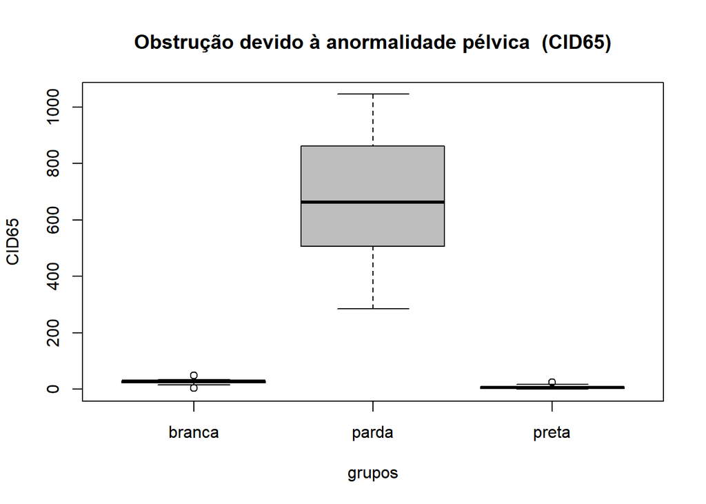

```r
# Boxplot para visualização
boxplot(CID65 ~ grupos,
        data = dados,
        col = c("white", "gray", "tan"),
        main = "Obstrução devido à anormalidade pélvica  (CID65)")
```

### 6.1.5 Comparação de grupos Teste Dunn - cid66

```r
# Teste de Dunn para a coluna 66
resultado <- dunn_test(CID66 ~ grupos,
                       data = dados,
                       p.adjust.method = "bonferroni")
print(resultado)
```

```
## # A tibble: 3 × 9
##   .y.   group1 group2    n1    n2 statistic          p      p.adj p.adj.signif
## * <chr> <chr>  <chr>  <int> <int>     <dbl>      <dbl>      <dbl> <chr>
## 1 CID66 branca parda     16    16     4.69  0.00000273 0.00000819 ****
## 2 CID66 branca preta     16    16     0.116 0.908      1          ns
## 3 CID66 parda  preta     16    16    -4.57  0.00000478 0.0000143  ****
```

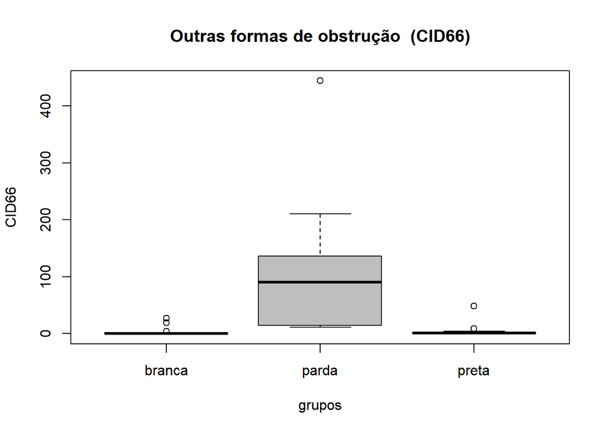

```r
# Boxplot para visualização
boxplot(CID66 ~ grupos,
        data = dados,
        col = c("white", "gray", "tan"),
        main = "Outras formas de obstrução  (CID66)")
```

### 6.1.6 Comparação de grupos Teste Dunn - cid68

```r
# Teste de Dunn para a coluna 68
resultado <- dunn_test(CID68 ~ grupos,
                       data = dados,
                       p.adjust.method = "bonferroni")
print(resultado)
```

```
## # A tibble: 3 × 9
##   .y.   group1 group2    n1    n2 statistic        p    p.adj p.adj.signif
## * <chr> <chr>  <chr>  <int> <int>     <dbl>    <dbl>    <dbl> <chr>
## 1 CID68 branca parda     16    16      3.40 6.65e- 4 1.99e- 3 **
## 2 CID68 branca preta     16    16     -2.89 3.82e- 3 1.15e- 2 *
## 3 CID68 parda  preta     16    16     -6.30 3.05e-10 9.16e-10 ****
```

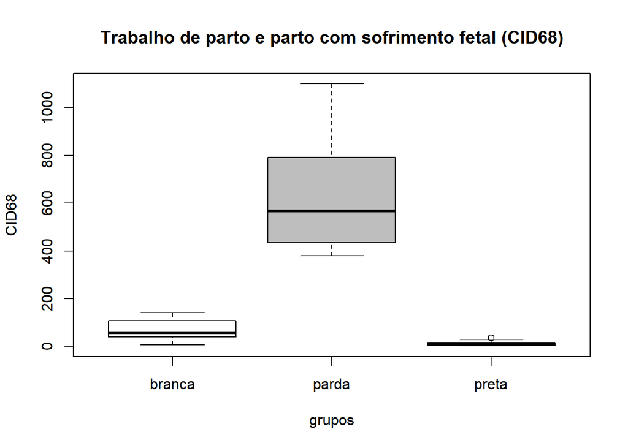

```r
# Boxplot para visualização
boxplot(CID68 ~ grupos,
        data = dados,
        col = c("white", "gray", "tan"),
        main = "Trabalho de parto e parto com sofrimento fetal (CID68)")
```